# Отчёт по лабораторной работе №13

## Внесение изменений в настройки внутреннего окружения виртуальных машин

В каталоге /vagrant/provision/server создадим исполняемый файл nfs.sh (рис. 36).

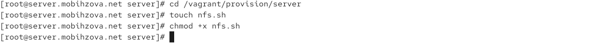

Рисунок 36: Создание исполняемого файла nfs.sh на сервере.

## Внесение изменений в настройки внутреннего окружения виртуальных машин

Откроем файл на редактирование и пропишем в нём скрипт для автоматической настройки NFS (рис. 37).

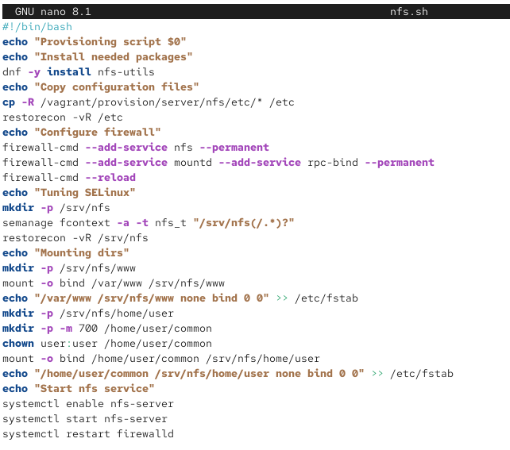

Рисунок 37: Содержимое скрипта nfs.sh для сервера.

## Внесение изменений в настройки внутреннего окружения виртуальных машин

[figure not shown]

Рисунок 38: Переход в каталог provisioning на клиенте.

## Внесение изменений в настройки внутреннего окружения виртуальных машин

В каталоге /vagrant/provision/client создадим исполняемый файл nfs.sh (рис. 39).

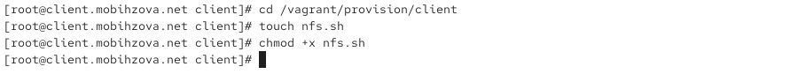

## Внесение изменений в настройки внутреннего окружения виртуальных машин

Откроем файл на редактирование и пропишем в нём скрипт для автоматической настройки NFS-клиента (рис. 40).

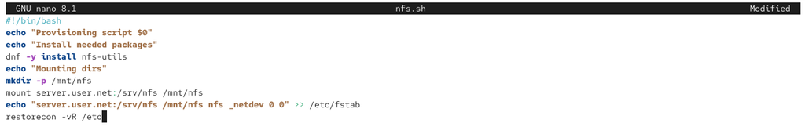

Рисунок 40: Содержимое скрипта nfs.sh для клиента.

## Внесение изменений в настройки внутреннего окружения виртуальных машин

Для отработки созданных скриптов во время загрузки виртуальных машин server и client в конфигурационном файле Vagrantfile необходимо добавить соответствующие разделы конфигураций (рис. 41, рис. 42).

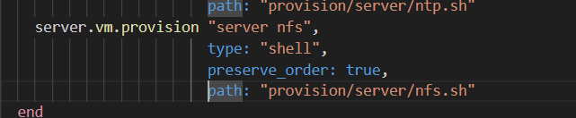

Рисунок 41: Настройка provisioning для сервера в Vagrantfile.

## Внесение изменений в настройки внутреннего окружения виртуальных машин

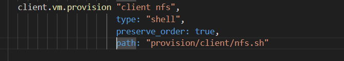

Рисунок 42: Настройка provisioning для клиента в Vagrantfile.

# Выводы

## Выводы

В ходе выполнения лабораторной работы были приобретены практические навыки настройки сервера NFS для удалённого доступа к ресурсам.